# Part I - Prosper Loan Data Exploration

### *LoanOriginalAmount By SimpleInterest*

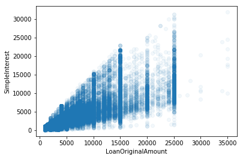

```python
sb.regplot(data = loan_var, x = 'LoanOriginalAmount', y = 'SimpleInterest', truncate=False, x_jitter=0.3, scatter_kws={'alpha':1/20},fit_reg=False);

# plt.scatter(data =loan_var, x = 'LoanOriginalAmount', y = 'SimpleInterest', alpha=1/20);
```

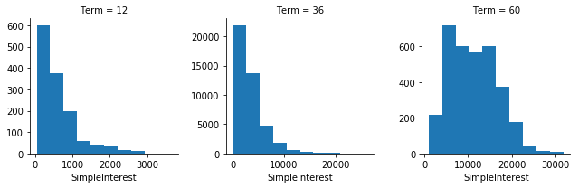

```python
# bins=np.arange(0,loan_var['DebtToIncomeRatio'].max()+0.02,0.02)
g = sb.FacetGrid(data = loan_var, col = 'Term',sharex=False,sharey=False)
g.map(plt.hist,'SimpleInterest');
# plt.xlim(0,1);
```

### *Observation*

```
There is a Positive correlation between SimpleInterest and LoanOriginalAmount,I will Look to see how These Two
variables fare against The loanOutcome variable In The Multivarate Section of This analysis .
```

### *MonthlyloanPayment & LoanOriginalAmount*

```
What Relationship Does These Twoo variables have
```

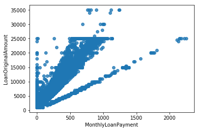

```python
sb.regplot(data = loan_var, x = 'MonthlyLoanPayment', y = 'LoanOriginalAmount', truncate=False, fit_reg=False);
# plt.scatter(data =loan_var, x = 'LoanOriginalAmount', y = 'SimpleInterest', alpha=1/20);
```

```python
loan_var[['MonthlyLoanPayment','LoanOriginalAmount']].corr()
```

|  | MonthlyLoanPayment | LoanOriginalAmount |
| --- | --- | --- |
| MonthlyLoanPayment | 1.000000 | 0.930709 |
| LoanOriginalAmount | 0.930709 | 1.000000 |

```
Theres a positive correlation between these two variables
```

### *LoanOriginalAmount & LoanOutcome*

```
 Does Amount of Loan taken Influence a loan Outcome ?
```

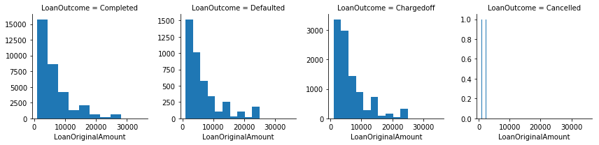

```python
# bins=np.arange(0,loan_var['DebtToIncomeRatio'].max()+0.02,0.02)
g = sb.FacetGrid(data = loan_var, col = 'LoanOutcome',sharey=False)
g.map(plt.hist,'LoanOriginalAmount');
# plt.xlim(0,1);
```

### *Observation*

```
Loan Amount Doesnt Influence a Loan Outcome at least not explicitly, will see how these two variables fare against
other Variables such as IsBorrowerHomeowner and Recommendations.
```

### *EmploymentStatus & IncomeRange by LoanOutcome*

```
Does Employment Status and Income Range Influence a Loan Outcome
```

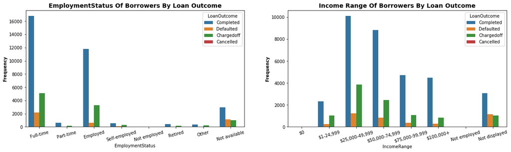

```python
plt.figure(figsize = [20, 5])
# EmploymentStatus on the left
plt.subplot(1, 2, 1)
sb.countplot(data=loan_var,x='EmploymentStatus',hue='LoanOutcome')
plt.title('EmploymentStatus Of Borrowers By Loan Outcome',fontsize = 14, fontweight ='bold')
plt.ylabel('Frequency',fontsize = 10, fontweight ='bold')
plt.xticks(rotation=15);
# Income Range on The right
plt.subplot(1, 2, 2)
sb.countplot(data=loan_var,x='IncomeRange',hue='LoanOutcome')
plt.title('Income Range Of Borrowers By Loan Outcome',fontsize = 14, fontweight ='bold')
plt.ylabel('Frequency',fontsize = 10, fontweight ='bold')
plt.xticks(rotation=15);
```

### *Obersevation*

```
16k5 Borrowers That are full Time employed completed their loan , while 2k Borrowers from This Category Defaulted on
their loan.The Employed Category has over 11k completed Loans with a very low default rate .With respect to The rate
of Completed Loans per loan defaults ,The Not available EmploymentStatus has the higheest rate of Defaults .
Borrowers Earning Between $75k to over $100k alongside Borrowers Earning Between 1 to 24.9k Have a Good Completion
rate with a small amount of Borrowers Defaulting On Their Loans.The Not Displayed Income Range have The Highest
Rate of Defaults Compared to how many loans were completed .
```

### *DTI & Recommendations*

```
DTI distribution By number of Recommendations
```

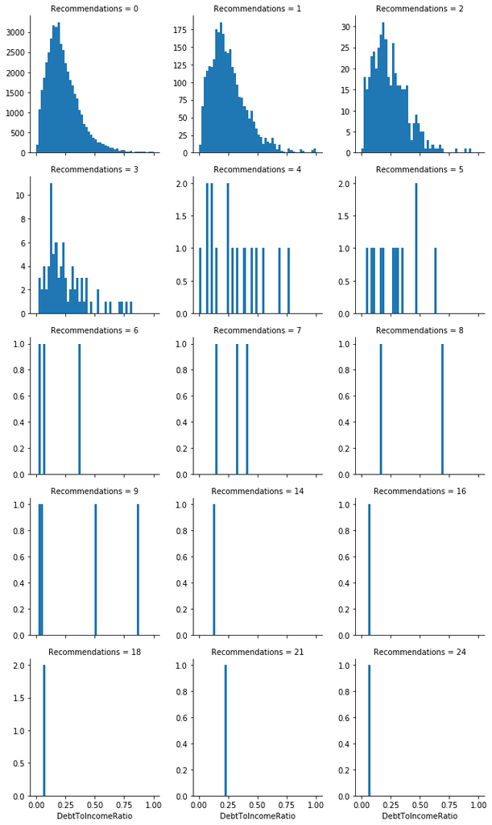

```python
bins=np.arange(0,loan_var['DebtToIncomeRatio'].max()+0.02,0.02)
g = sb.FacetGrid(data = loan_var, col = 'Recommendations',sharey=False,col_wrap=3)
g.map(plt.hist, "DebtToIncomeRatio",bins=bins);
```

### *Observation*

```
Borrowers DTI gets Better(Smaller) with Increase in Number of Recommendations.
```

### Talk about some of the relationships you observed in this part of the investigation. How did the feature(s) of interest vary with other features in the dataset?

```
Borrowers with Recommendations are more likely to complete a loan rather  than default,The DTI of Borrowers with
completed loans has a median value of 0.2 and a mean value of 0.21 which is lower compared to other loanOutcome.
IsBorrowerHomeowner Doesnt influence a LoanOutcome since the proportionof Completed and Defaulted loans were
about even among Borrowers that owns a Home and Borrowers who dont.
Most Defaults in loans stem from Borrowers with a " Not Available" in their ListingCategory and EmploymentStatus,
and also a  "Not Displayed" value for Their IncomeRange.Loans with a Year Duration has The Lowest Amount of Defaults.
```

### Did you observe any interesting relationships between the other features (not the main feature(s) of interest)?

```
There's a positive Correlation between loan amount Taken and the Simple Interest on it .Borrowers with recommendations
have a better DTI .
```

## Multivariate Exploration

### *MonthlyLoanPayment vs LoanOriginalAmount By LoanOutcome*

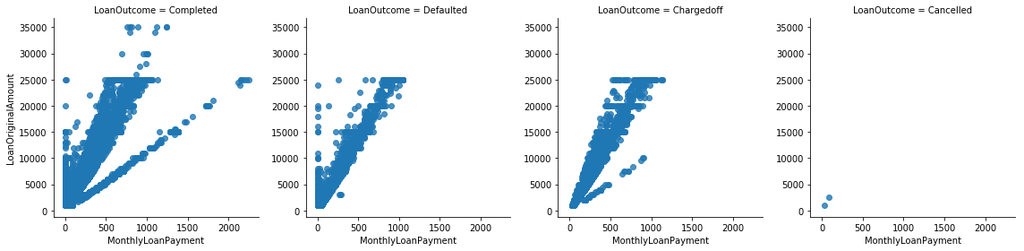

```python
g = sb.FacetGrid(data = loan_var, col = 'LoanOutcome', size = 4)
g.map(sb.regplot,'MonthlyLoanPayment' ,'LoanOriginalAmount',fit_reg=False);
```

```
Each Loan outcome have a distinct pattern to them.Defaulted and Charged off loans have a max LoanOriginalAmount of
about 25k dollars and a max MonthlyLoanPayment of about 1k dollarsb,for Completed loans these boundaries are shattered ,
LoanOriginalAmount extends to over 35k dollars with a max MonthlyLoanPayment of over 2k dollars .
```

### *IsBorrowerHomeowner*

```
IsBorrowerHomeowner Variable will be explored with The LoanOutcome variable along Other variables such as DTI ,
monthlyLoanPayment and LoanOriginalAmount
```

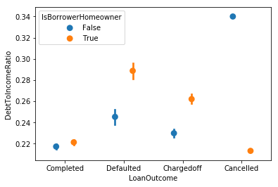

```python
sb.pointplot(data = loan_var, x = 'LoanOutcome', y = 'DebtToIncomeRatio', hue = 'IsBorrowerHomeowner',
                  dodge = 0.3, linestyles = "");
```

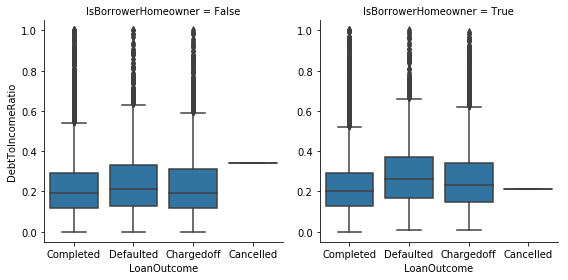

```python
g = sb.FacetGrid(data = loan_var, col = 'IsBorrowerHomeowner', size = 4)
g.map(sb.boxplot, 'LoanOutcome', 'DebtToIncomeRatio');
```

```
The DTI distribution of Borrowers That owns a Home and Borrowers Who dont are about the the same ,with Borrowers
who arent Homeowners looking to have a slightly better Distribution.
```

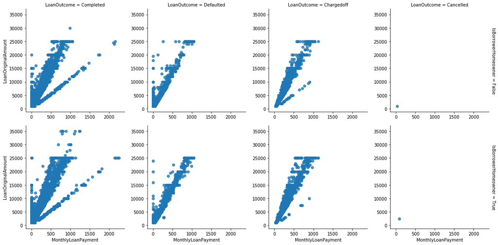

```python
# Facetting The previous scatter plot by the IsBorrowerHomeowner variable
g = sb.FacetGrid(data = loan_var, col = 'LoanOutcome',row='IsBorrowerHomeowner', size = 4,margin_titles = True)
g.map(sb.regplot,'MonthlyLoanPayment' ,'LoanOriginalAmount',fit_reg=False);
```

```
Once again Borrowers that owns a home and Borrowers who dont have about the same distribution ,but an handful of
Borrowers that takes loan ranging from 25k to over 35k dollars are HomeOwners with a High Completion Rate.
```

### Talk about some of the relationships you observed in this part of the investigation. Were there features that strengthened each other in terms of looking at your feature(s) of interest?

```
Mostly  Homeowners Take a loan amount between 25k and over 35k Dollars with a Good Completion rate ,Defaulted  and
Charged off Loans having a limiting range of 25k dollars in loan amount and 1k dollars in MonthlyLoanPayment ,Loans
Beyond These Limits Have a good Completion rate .
```

### Were there any interesting or surprising interactions between features?

```
Owning a Home was  earlier suspected to  be pivotal in The Completion of a Loan, But That wasnt The Case when The
IsBorrowerHomeowner Variable Was explored along with Other variables such as DebtToIncomeRatio,LoanOutcome,
MonthlyLoanOutcome and LoanOriginalAmount.It was Found out To have The same Distribution with Borrowers that arent
Homeowners.
```

## Conclusions

```
Borrowers with a Non Available value for their ListingCategory and EmploymentStatus,Not Displayed value for their
IncomeRange are prone to Default on loans .Homeowners and Non Homeowners have about the same distribution in Loan
Completion and Defaults .The more number of Recommendations a Borrower gets The more Likely They will complete
their loan.Borrowers with Good DTI Tend To Complete Their Loans .Loans with a 1 year Duration have the highest
completion rate with little Defaults .Borrowers With a ListingCategory of Auto and Auto related values  such as
Motorcycles ,Boats ,RV  also have a good Completion rate.
```